# Example evaluation of FOCUS Laboratory Data L1 to L3

Johannes Ranke

Last change 18 May 2023 (rebuilt 2025-02-16)

# Laboratory Data L1

The following code defines example dataset L1 from the FOCUS kinetics report, p. 284:

```r
library("mkin", quietly = TRUE)
FOCUS_2006_L1 = data.frame(
  t = rep(c(0, 1, 2, 3, 5, 7, 14, 21, 30), each = 2),
  parent = c(88.3, 91.4, 85.6, 84.5, 78.9, 77.6,
             72.0, 71.9, 50.3, 59.4, 47.0, 45.1,
             27.7, 27.3, 10.0, 10.4, 2.9, 4.0))
FOCUS_2006_L1_mkin <- mkin_wide_to_long(FOCUS_2006_L1)
```

Here we use the assumptions of simple first order (SFO), the case of declining rate constant over time (FOMC) and the case of two different phases of the kinetics (DFOP). For a more detailed discussion of the models, please see the FOCUS kinetics report.

Since mkin version 0.9-32 (July 2014), we can use shorthand notation like `"SFO"` for parent only degradation models. The following two lines fit the model and produce the summary report of the model fit. This covers the numerical analysis given in the FOCUS report.

```r
m.L1.SFO <- mkinfit("SFO", FOCUS_2006_L1_mkin, quiet = TRUE)
summary(m.L1.SFO)
```

```
## mkin version used for fitting:    0.9.49.8
## R version used for fitting:       4.4.2
## Date of fit:     Sun Feb 16 14:25:37 2025
## Date of summary: Sun Feb 16 14:25:37 2025
##
## Equations:
## d_parent/dt = - k_parent_sink * parent
##
## Model predictions using solution type analytical
##
## Fitted using 133 model solutions performed in 0.106 s
##
## Error model: Constant variance
##
## Error model algorithm: OLS
##
## Starting values for parameters to be optimised:
##               value   type
## parent_0      89.85  state
## k_parent_sink  0.10 deparm
##
## Starting values for the transformed parameters actually optimised:
##                       value lower upper
## parent_0          89.850000  -Inf   Inf
## log_k_parent_sink -2.302585  -Inf   Inf
##
## Fixed parameter values:
## None
##
## Optimised, transformed parameters with symmetric confidence intervals:
##                   Estimate Std. Error  Lower  Upper
## parent_0            92.470    1.28200 89.740 95.200
## log_k_parent_sink   -2.347    0.03763 -2.428 -2.267
## sigma                2.780    0.46330  1.792  3.767
##
## Parameter correlation:
##                     parent_0 log_k_parent_sink      sigma
## parent_0           1.000e+00         6.186e-01 -1.516e-09
## log_k_parent_sink  6.186e-01         1.000e+00 -3.124e-09
## sigma             -1.516e-09        -3.124e-09  1.000e+00
```

[output cut: 28 more lines]

```
##     1   parent     84.5    84.039   0.4610
##     2   parent     78.9    76.376   2.5241
##     2   parent     77.6    76.376   1.2241
##     3   parent     72.0    69.412   2.5884
##     3   parent     71.9    69.412   2.4884
##     5   parent     50.3    57.330  -7.0301
##     5   parent     59.4    57.330   2.0699
##     7   parent     47.0    47.352  -0.3515
##     7   parent     45.1    47.352  -2.2515
##    14   parent     27.7    24.247   3.4528
##    14   parent     27.3    24.247   3.0528
##    21   parent     10.0    12.416  -2.4163
##    21   parent     10.4    12.416  -2.0163
##    30   parent      2.9     5.251  -2.3513
##    30   parent      4.0     5.251  -1.2513
```

A plot of the fit is obtained with the plot function for mkinfit objects.

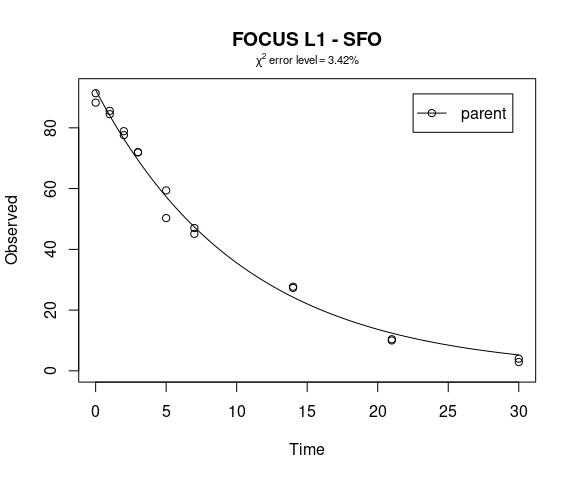

```r
plot(m.L1.SFO, show_errmin = TRUE, main = "FOCUS L1 - SFO")
```

The residual plot can be easily obtained by

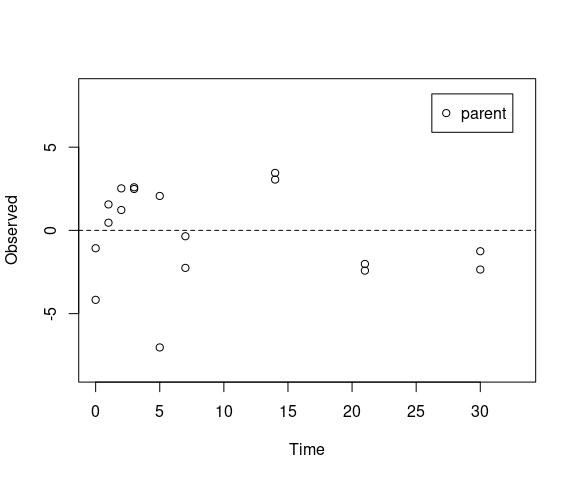

```r
mkinresplot(m.L1.SFO, ylab = "Observed", xlab = "Time")
```

For comparison, the FOMC model is fitted as well, and the *χ*<sup>2</sup> error level is checked.

```r
m.L1.FOMC <- mkinfit("FOMC", FOCUS_2006_L1_mkin, quiet=TRUE)
```

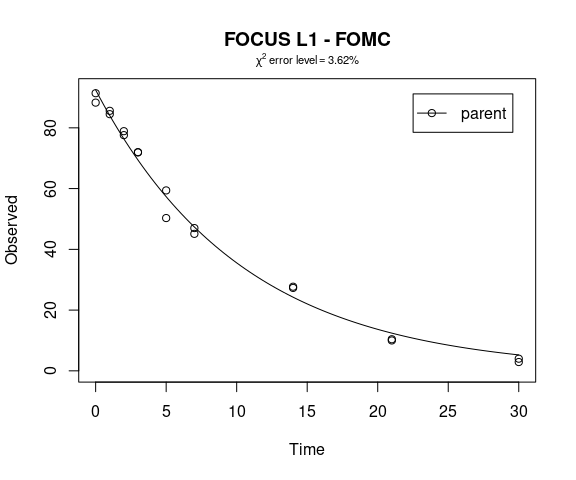

```r
plot(m.L1.FOMC, show_errmin = TRUE, main = "FOCUS L1 - FOMC")
```

```r
summary(m.L1.FOMC, data = FALSE)
```

```
## Warning in sqrt(diag(covar)): NaNs produced
```

```
## Warning: In subset.data.frame(fit$fixed, type = "state") :
##  extra argument 'type' will be disregarded
```

```
## Warning in cov2cor(ans$covar): diag(V) had non-positive or NA entries; the
## non-finite result may be dubious
```

```
## mkin version used for fitting:    0.9.49.8
## R version used for fitting:       4.4.2
## Date of fit:     Sun Feb 16 14:25:37 2025
## Date of summary: Sun Feb 16 14:25:37 2025
##
##
## Warning: Optimisation did not converge:
## false convergence (8)
##
##
## Equations:
## d_parent/dt = - (alpha/beta) * 1/((time/beta) + 1) * parent
##
## Model predictions using solution type analytical
##
## Fitted using 342 model solutions performed in 0.242 s
##
## Error model: Constant variance
##
## Error model algorithm: OLS
##
## Starting values for parameters to be optimised:
##          value   type
## parent_0 89.85  state
## alpha     1.00 deparm
## beta     10.00 deparm
##
## Starting values for the transformed parameters actually optimised:
##               value lower upper
## parent_0  89.850000  -Inf   Inf
## log_alpha  0.000000  -Inf   Inf
## log_beta   2.302585  -Inf   Inf
##
## Fixed parameter values:
## None
##
## Optimised, transformed parameters with symmetric confidence intervals:
##           Estimate Std. Error  Lower  Upper
## parent_0     92.47     1.2820 89.720 95.220
## log_alpha    13.20        NaN    NaN    NaN
```

[output cut: 13 more lines]

```
## for estimators of untransformed parameters.
##           Estimate t value Pr(>t)  Lower  Upper
## parent_0 9.247e+01      NA     NA 89.720 95.220
## alpha    5.386e+05      NA     NA     NA     NA
## beta     5.633e+06      NA     NA     NA     NA
## sigma    2.780e+00      NA     NA  1.792  3.768
##
## FOCUS Chi2 error levels in percent:
##          err.min n.optim df
## All data   3.619       3  6
## parent     3.619       3  6
##
## Estimated disappearance times:
##         DT50  DT90 DT50back
## parent 7.249 24.08    7.249
```

We get a warning that the default optimisation algorithm `Port` did not converge, which is an indication that the model is overparameterised, *i.e.* contains too many parameters that are ill-defined as a consequence.

And in fact, due to the higher number of parameters, and the lower number of degrees of freedom of the fit, the *χ*<sup>2</sup> error level is actually higher for the FOMC model (3.6%) than for the SFO model (3.4%). Additionally, the parameters `log_alpha` and `log_beta` internally fitted in the model have excessive confidence intervals, that span more than 25 orders of magnitude (!) when backtransformed to the scale of `alpha` and `beta`. Also, the t-test for significant difference from zero does not indicate such a significant difference, with p-values greater than 0.1, and finally, the parameter correlation of `log_alpha` and `log_beta` is 1.000, clearly indicating that the model is overparameterised.

The *χ*<sup>2</sup> error levels reported in Appendix 3 and Appendix 7 to the FOCUS kinetics report are rounded to integer percentages and partly deviate by one percentage point from the results calculated by mkin. The reason for this is not known. However, mkin gives the same *χ*<sup>2</sup> error levels as the kinfit package and the calculation routines of the kinfit package have been extensively compared to the results obtained by the KinGUI software, as documented in the kinfit package vignette. KinGUI was the first widely used standard package in this field. Also, the calculation of *χ*<sup>2</sup> error levels was compared with KinGUII, CAKE and DegKin manager in a project sponsored by the German Umweltbundesamt (Ranke 2014).

# Laboratory Data L2

The following code defines example dataset L2 from the FOCUS kinetics report, p. 287:

```r
FOCUS_2006_L2 = data.frame(
  t = rep(c(0, 1, 3, 7, 14, 28), each = 2),
  parent = c(96.1, 91.8, 41.4, 38.7,
             19.3, 22.3, 4.6, 4.6,
             2.6, 1.2, 0.3, 0.6))
FOCUS_2006_L2_mkin <- mkin_wide_to_long(FOCUS_2006_L2)
```

## SFO fit for L2

Again, the SFO model is fitted and the result is plotted. The residual plot can be obtained simply by adding the argument `show_residuals` to the plot command.

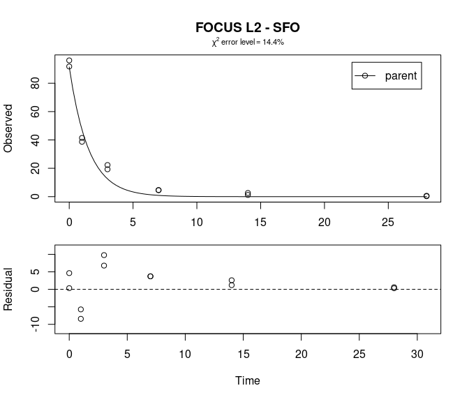

```r
m.L2.SFO <- mkinfit("SFO", FOCUS_2006_L2_mkin, quiet=TRUE)
plot(m.L2.SFO, show_residuals = TRUE, show_errmin = TRUE,
     main = "FOCUS L2 - SFO")
```

The *χ*<sup>2</sup> error level of 14% suggests that the model does not fit very well. This is also obvious from the plots of the fit, in which we have included the residual plot.

In the FOCUS kinetics report, it is stated that there is no apparent systematic error observed from the residual plot up to the measured DT90 (approximately at day 5), and there is an underestimation beyond that point.

We may add that it is difficult to judge the random nature of the residuals just from the three samplings at days 0, 1 and 3. Also, it is not clear *a priori* why a consistent underestimation after the approximate DT90 should be irrelevant. However, this can be rationalised by the fact that the FOCUS fate models generally only implement SFO kinetics.

## FOMC fit for L2

For comparison, the FOMC model is fitted as well, and the *χ*<sup>2</sup> error level is checked.

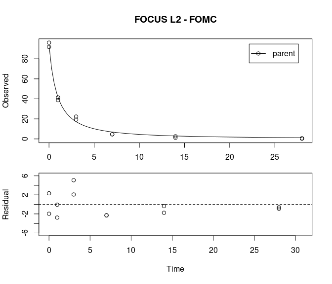

```r
m.L2.FOMC <- mkinfit("FOMC", FOCUS_2006_L2_mkin, quiet = TRUE)
plot(m.L2.FOMC, show_residuals = TRUE,
     main = "FOCUS L2 - FOMC")
```

```r
summary(m.L2.FOMC, data = FALSE)
```

```
## mkin version used for fitting:    0.9.49.8
## R version used for fitting:       4.4.2
## Date of fit:     Sun Feb 16 14:25:38 2025
## Date of summary: Sun Feb 16 14:25:38 2025
##
## Equations:
## d_parent/dt = - (alpha/beta) * 1/((time/beta) + 1) * parent
##
## Model predictions using solution type analytical
##
## Fitted using 239 model solutions performed in 0.167 s
##
## Error model: Constant variance
##
## Error model algorithm: OLS
##
## Starting values for parameters to be optimised:
##          value   type
## parent_0 93.95  state
## alpha     1.00 deparm
## beta     10.00 deparm
##
## Starting values for the transformed parameters actually optimised:
##               value lower upper
## parent_0  93.950000  -Inf   Inf
## log_alpha  0.000000  -Inf   Inf
## log_beta   2.302585  -Inf   Inf
##
## Fixed parameter values:
## None
##
## Optimised, transformed parameters with symmetric confidence intervals:
##           Estimate Std. Error    Lower   Upper
## parent_0   93.7700     1.6130 90.05000 97.4900
## log_alpha   0.3180     0.1559 -0.04149  0.6776
## log_beta    0.2102     0.2493 -0.36460  0.7850
## sigma       2.2760     0.4645  1.20500  3.3470
##
## Parameter correlation:
##             parent_0  log_alpha   log_beta      sigma
```

[output cut: 8 more lines]

```
## for estimators of untransformed parameters.
##          Estimate t value    Pr(>t)   Lower  Upper
## parent_0   93.770  58.120 4.267e-12 90.0500 97.490
## alpha       1.374   6.414 1.030e-04  0.9594  1.969
## beta        1.234   4.012 1.942e-03  0.6945  2.192
## sigma       2.276   4.899 5.977e-04  1.2050  3.347
##
## FOCUS Chi2 error levels in percent:
##          err.min n.optim df
## All data   6.205       3  3
## parent     6.205       3  3
##
## Estimated disappearance times:
##          DT50  DT90 DT50back
## parent 0.8092 5.356    1.612
```

The error level at which the *χ*<sup>2</sup> test passes is much lower in this case. Therefore, the FOMC model provides a better description of the data, as less experimental error has to be assumed in order to explain the data.

## DFOP fit for L2

Fitting the four parameter DFOP model further reduces the *χ*<sup>2</sup> error level.

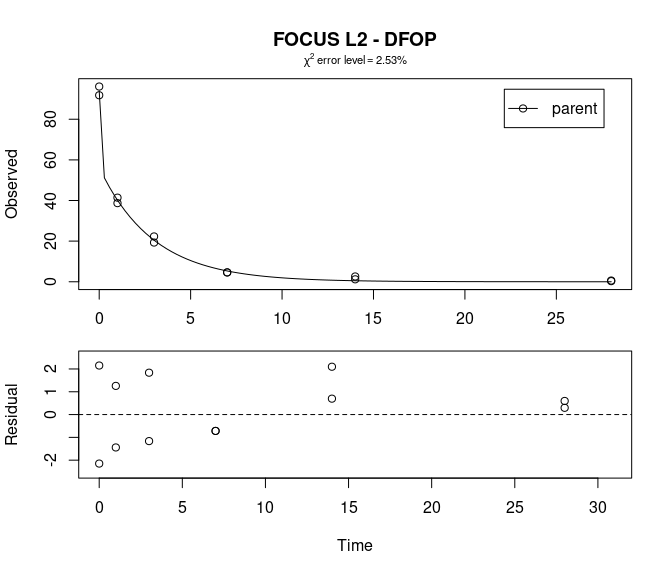

```r
m.L2.DFOP <- mkinfit("DFOP", FOCUS_2006_L2_mkin, quiet = TRUE)
plot(m.L2.DFOP, show_residuals = TRUE, show_errmin = TRUE,
     main = "FOCUS L2 - DFOP")
```

```r
summary(m.L2.DFOP, data = FALSE)
```

```
## mkin version used for fitting:    0.9.49.8
## R version used for fitting:       4.4.2
## Date of fit:     Sun Feb 16 14:25:39 2025
## Date of summary: Sun Feb 16 14:25:39 2025
##
## Equations:
## d_parent/dt = - ((k1 * g * exp(-k1 * time) + k2 * (1 - g) * exp(-k2 *
##            time)) / (g * exp(-k1 * time) + (1 - g) * exp(-k2 * time)))
##            * parent
##
## Model predictions using solution type analytical
##
## Fitted using 572 model solutions performed in 0.399 s
##
## Error model: Constant variance
##
## Error model algorithm: OLS
##
## Starting values for parameters to be optimised:
##          value   type
## parent_0 93.95  state
## k1        0.10 deparm
## k2        0.01 deparm
## g         0.50 deparm
##
## Starting values for the transformed parameters actually optimised:
##              value lower upper
## parent_0 93.950000  -Inf   Inf
## log_k1   -2.302585  -Inf   Inf
## log_k2   -4.605170  -Inf   Inf
## g_ilr     0.000000  -Inf   Inf
##
## Fixed parameter values:
## None
##
## Optimised, transformed parameters with symmetric confidence intervals:
##          Estimate Std. Error      Lower     Upper
## parent_0  93.9500  9.998e-01    91.5900   96.3100
## log_k1     3.1370  2.376e+03 -5615.0000 5622.0000
## log_k2    -1.0880  6.285e-02    -1.2370   -0.9394
```

[output cut: 15 more lines]

```
##          Estimate   t value    Pr(>t)   Lower   Upper
## parent_0  93.9500 9.397e+01 2.036e-12 91.5900 96.3100
## k1        23.0400 4.303e-04 4.998e-01  0.0000     Inf
## k2         0.3369 1.591e+01 4.697e-07  0.2904  0.3909
## g          0.4016 1.680e+01 3.238e-07  0.3466  0.4591
## sigma      1.4140 4.899e+00 8.776e-04  0.7314  2.0960
##
## FOCUS Chi2 error levels in percent:
##          err.min n.optim df
## All data    2.53       4  2
## parent      2.53       4  2
##
## Estimated disappearance times:
##          DT50  DT90 DT50_k1 DT50_k2
## parent 0.5335 5.311 0.03009   2.058
```

Here, the DFOP model is clearly the best-fit model for dataset L2 based on the chi^2 error level criterion.

# Laboratory Data L3

The following code defines example dataset L3 from the FOCUS kinetics report, p. 290.

```r
FOCUS_2006_L3 = data.frame(
  t = c(0, 3, 7, 14, 30, 60, 91, 120),
  parent = c(97.8, 60, 51, 43, 35, 22, 15, 12))
FOCUS_2006_L3_mkin <- mkin_wide_to_long(FOCUS_2006_L3)
```

## Fit multiple models

As of mkin version 0.9-39 (June 2015), we can fit several models to one or more datasets in one call to the function `mmkin`. The datasets have to be passed in a list, in this case a named list holding only the L3 dataset prepared above.

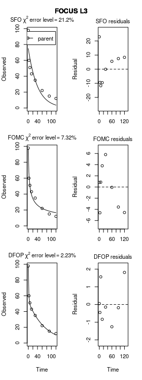

```r
# Only use one core here, not to offend the CRAN checks
mm.L3 <- mmkin(c("SFO", "FOMC", "DFOP"), cores = 1,
               list("FOCUS L3" = FOCUS_2006_L3_mkin), quiet = TRUE)
plot(mm.L3)
```

The *χ*<sup>2</sup> error level of 21% as well as the plot suggest that the SFO model does not fit very well. The FOMC model performs better, with an error level at which the *χ*<sup>2</sup> test passes of 7%. Fitting the four parameter DFOP model further reduces the *χ*<sup>2</sup> error level considerably.

## Accessing mmkin objects

The objects returned by mmkin are arranged like a matrix, with models as a row index and datasets as a column index.

We can extract the summary and plot for *e.g.* the DFOP fit, using square brackets for indexing which will result in the use of the summary and plot functions working on mkinfit objects.

```r
summary(mm.L3[["DFOP", 1]])
```

```
## mkin version used for fitting:    0.9.49.8
## R version used for fitting:       4.4.2
## Date of fit:     Sun Feb 16 14:25:40 2025
## Date of summary: Sun Feb 16 14:25:40 2025
##
## Equations:
## d_parent/dt = - ((k1 * g * exp(-k1 * time) + k2 * (1 - g) * exp(-k2 *
##            time)) / (g * exp(-k1 * time) + (1 - g) * exp(-k2 * time)))
##            * parent
##
## Model predictions using solution type analytical
##
## Fitted using 373 model solutions performed in 0.258 s
##
## Error model: Constant variance
##
## Error model algorithm: OLS
##
## Starting values for parameters to be optimised:
##          value   type
## parent_0 97.80  state
## k1        0.10 deparm
## k2        0.01 deparm
## g         0.50 deparm
##
## Starting values for the transformed parameters actually optimised:
##              value lower upper
## parent_0 97.800000  -Inf   Inf
## log_k1   -2.302585  -Inf   Inf
## log_k2   -4.605170  -Inf   Inf
## g_ilr     0.000000  -Inf   Inf
##
## Fixed parameter values:
## None
##
## Optimised, transformed parameters with symmetric confidence intervals:
##          Estimate Std. Error   Lower      Upper
## parent_0  97.7500    1.01900 94.5000 101.000000
## log_k1    -0.6612    0.10050 -0.9812  -0.341300
## log_k2    -4.2860    0.04322 -4.4230  -4.148000
```

[output cut: 26 more lines]

```
##
## Estimated disappearance times:
##         DT50 DT90 DT50_k1 DT50_k2
## parent 7.464  123   1.343   50.37
##
## Data:
##  time variable observed predicted residual
##     0   parent     97.8     97.75  0.05396
##     3   parent     60.0     60.45 -0.44933
##     7   parent     51.0     49.44  1.56338
##    14   parent     43.0     43.84 -0.83632
##    30   parent     35.0     35.15 -0.14707
##    60   parent     22.0     23.26 -1.25919
##    91   parent     15.0     15.18 -0.18181
##   120   parent     12.0     10.19  1.81395
```

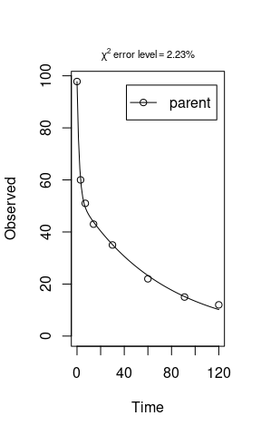

```r
plot(mm.L3[["DFOP", 1]], show_errmin = TRUE)
```

Here, a look to the model plot, the confidence intervals of the parameters and the correlation matrix suggest that the parameter estimates are reliable, and the DFOP model can be used as the best-fit model based on the *χ*<sup>2</sup> error level criterion for laboratory data L3.

This is also an example where the standard t-test for the parameter `g_ilr` is misleading, as it tests for a significant difference from zero. In this case, zero appears to be the correct value for this parameter, and the confidence interval for the backtransformed parameter `g` is quite narrow.

# Laboratory Data L4

The following code defines example dataset L4 from the FOCUS kinetics report, p. 293:

```r
FOCUS_2006_L4 = data.frame(
  t = c(0, 3, 7, 14, 30, 60, 91, 120),
  parent = c(96.6, 96.3, 94.3, 88.8, 74.9, 59.9, 53.5, 49.0))
FOCUS_2006_L4_mkin <- mkin_wide_to_long(FOCUS_2006_L4)
```

Fits of the SFO and FOMC models, plots and summaries are produced below:

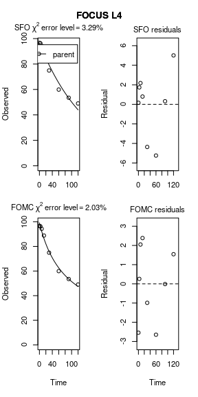

```r
# Only use one core here, not to offend the CRAN checks
mm.L4 <- mmkin(c("SFO", "FOMC"), cores = 1,
               list("FOCUS L4" = FOCUS_2006_L4_mkin),
               quiet = TRUE)
plot(mm.L4)
```

The *χ*<sup>2</sup> error level of 3.3% as well as the plot suggest that the SFO model fits very well. The error level at which the *χ*<sup>2</sup> test passes is slightly lower for the FOMC model. However, the difference appears negligible.

```r
summary(mm.L4[["SFO", 1]], data = FALSE)
```

```
## mkin version used for fitting:    0.9.49.8
## R version used for fitting:       4.4.2
## Date of fit:     Sun Feb 16 14:25:40 2025
## Date of summary: Sun Feb 16 14:25:40 2025
##
## Equations:
## d_parent/dt = - k_parent_sink * parent
##
## Model predictions using solution type analytical
##
## Fitted using 142 model solutions performed in 0.096 s
##
## Error model: Constant variance
##
## Error model algorithm: OLS
##
## Starting values for parameters to be optimised:
##               value   type
## parent_0       96.6  state
## k_parent_sink   0.1 deparm
##
## Starting values for the transformed parameters actually optimised:
##                       value lower upper
## parent_0          96.600000  -Inf   Inf
## log_k_parent_sink -2.302585  -Inf   Inf
##
## Fixed parameter values:
## None
##
## Optimised, transformed parameters with symmetric confidence intervals:
##                   Estimate Std. Error  Lower   Upper
## parent_0            96.440    1.69900 92.070 100.800
## log_k_parent_sink   -5.030    0.07059 -5.211  -4.848
## sigma                3.162    0.79050  1.130   5.194
##
## Parameter correlation:
##                    parent_0 log_k_parent_sink     sigma
## parent_0          1.000e+00         5.938e-01 3.430e-07
## log_k_parent_sink 5.938e-01         1.000e+00 5.885e-07
## sigma             3.430e-07         5.885e-07 1.000e+00
##
## Backtransformed parameters:
## Confidence intervals for internally transformed parameters are asymmetric.
## t-test (unrealistically) based on the assumption of normal distribution
## for estimators of untransformed parameters.
##                Estimate t value    Pr(>t)     Lower     Upper
## parent_0      96.440000   56.77 1.604e-08 92.070000 1.008e+02
## k_parent_sink  0.006541   14.17 1.578e-05  0.005455 7.842e-03
## sigma          3.162000    4.00 5.162e-03  1.130000 5.194e+00
##
## FOCUS Chi2 error levels in percent:
##          err.min n.optim df
## All data   3.287       2  6
## parent     3.287       2  6
##
## Resulting formation fractions:
##             ff
## parent_sink  1
##
## Estimated disappearance times:
##        DT50 DT90
## parent  106  352
```

```r
summary(mm.L4[["FOMC", 1]], data = FALSE)
```

```
## mkin version used for fitting:    0.9.49.8
## R version used for fitting:       4.4.2
## Date of fit:     Sun Feb 16 14:25:40 2025
## Date of summary: Sun Feb 16 14:25:40 2025
##
## Equations:
## d_parent/dt = - (alpha/beta) * 1/((time/beta) + 1) * parent
##
## Model predictions using solution type analytical
##
## Fitted using 224 model solutions performed in 0.151 s
##
## Error model: Constant variance
##
## Error model algorithm: OLS
##
## Starting values for parameters to be optimised:
##          value   type
## parent_0  96.6  state
## alpha      1.0 deparm
## beta      10.0 deparm
##
## Starting values for the transformed parameters actually optimised:
##               value lower upper
## parent_0  96.600000  -Inf   Inf
## log_alpha  0.000000  -Inf   Inf
## log_beta   2.302585  -Inf   Inf
##
## Fixed parameter values:
## None
##
## Optimised, transformed parameters with symmetric confidence intervals:
##           Estimate Std. Error   Lower    Upper
## parent_0   99.1400     1.2670 95.6300 102.7000
## log_alpha  -0.3506     0.2616 -1.0770   0.3756
## log_beta    4.1740     0.3938  3.0810   5.2670
## sigma       1.8300     0.4575  0.5598   3.1000
##
## Parameter correlation:
##             parent_0  log_alpha   log_beta      sigma
```

[output cut: 8 more lines]

```
## for estimators of untransformed parameters.
##          Estimate t value    Pr(>t)   Lower   Upper
## parent_0  99.1400  78.250 7.993e-08 95.6300 102.700
## alpha      0.7042   3.823 9.365e-03  0.3407   1.456
## beta      64.9800   2.540 3.201e-02 21.7800 193.900
## sigma      1.8300   4.000 8.065e-03  0.5598   3.100
##
## FOCUS Chi2 error levels in percent:
##          err.min n.optim df
## All data   2.029       3  5
## parent     2.029       3  5
##
## Estimated disappearance times:
##         DT50 DT90 DT50back
## parent 108.9 1644    494.9
```

# References

Ranke, Johannes. 2014. “Prüfung und Validierung von Modellierungssoftware als Alternative zu ModelMaker 4.0.” Umweltbundesamt Projektnummer 27452.